# **Simulação de Números Aleatórios**

Mauro Campos. Departamento de Estatística, UFES

01 de agosto de 2018

# 1 Motivação

**Resultado**. Seja $U\sim U(0,1)$ e $F$ uma função de distribuição acumulada. Se $X$ é definida por $X=F^{-1}(U)$, então $X\sim F$, onde $F^{-1}(u)=\inf\{x:F(x)\geq u\}$ é a inversa generalizada de $F$. Além disso, segue que $F(X)\sim U(0,1)$.

Este resultado, bem conhecido da Teoria de Probabilidades, informa que se uma amostra aleatória da distribuição $U(0,1)$ está disponível, então esta amostra pode ser usada para se obter uma amostra aleatória de uma distribuição $F$. É importante lembrar que uma amostra aleatória da distribuição $U(0,1)$ é simplesmente uma sequência de variáveis aleatórias independentes e uniformemente distribuídas no intervalo $(0,1)$.

[Voltar ao topo](http://www.maurocampos.com/cursos/estcomp/simulna.html)

# 2 Números aleatórios $\times$ números pseudo-aleatórios

**Números aleatórios no intervalo $(0,1)$** formam uma amostra aleatória da distribuição $U(0,1)$.

**Números pseudo-aleatórios no intervalo $(0,1)$** formam uma sequência de valores, normalmente gerados determinísticamente por um computador, que para todos os fins práticos imitam números aleatórios no intervalo $(0,1)$ (ou seja, imitam uma amostra aleatória da distribuição $U(0,1)$). Tecnicamente, isto significa que se um método é usado para computacionalmente gerar números pseudo-aleatórios no intervalo $(0,1)$, os valores gerados devem necessarimente passar por testes de aderência e de independência para serem utilizados como uma amostra aleatória da distribuição $U(0,1)$ em simulações computacionais de processos ou sistemas.

[Voltar ao topo](http://www.maurocampos.com/cursos/estcomp/simulna.html)

# 3 O método congruencial linear

O método congruencial linear é usado para gerar números pseudo-aleatórios $u_{1},u_{2},u_{3},\ldots$ no intervalo $(0,1)$. O método consiste de duas etapas:

1. Obtenha uma sequência $x_{1},x_{2},x_{3},\ldots$ de valores usando a recorrência $x_{k+1}=(a\cdot x_{k} + b) \mod m$ para $k=1,2,3,\ldots$, onde $a,b$ e $m$ são inteiros positivos e $x_{1}$ é escolhido tal que $0\leq x_{1}<m$.
2. Obtenha agora a sequência $u_{1},u_{2},u_{3},\ldots$, onde $u_{k}=x_{k}/m$ para $k=1,2,3,\ldots$.

# 4 Exemplos

**Exemplo**. Quando $a=6$, $b=7$, $m=5$ e $x_{1}=2$.

```r
kmax <- 15
a <- 6;b <- 7;m <- 5
x <- rep(NA,kmax);x[1] <- 2
for(k in 1:(kmax-1)){x[k+1] <- (a*x[k]+b)%%m}
u <- x/m;u
##  [1] 0.4 0.8 0.2 0.6 0.0 0.4 0.8 0.2 0.6 0.0 0.4 0.8 0.2 0.6 0.0
```

A sequência $(u_{k})_{k\geq 1}$ convergiu para um ciclo periódico de período $5$.

**Exemplo**. Quando $a=30$, $b=60$, $m=100$ e $x_{1}=64$.

```r
kmax <- 25
a <- 30;b <- 60;m <- 100
x <- rep(NA,kmax);x[1] <- 64
for(k in 1:(kmax-1)){x[k+1] <- (a*x[k]+b)%%m}
u <- x/m;u
##  [1] 0.64 0.80 0.60 0.60 0.60 0.60 0.60 0.60 0.60 0.60 0.60 0.60 0.60 0.60
## [15] 0.60 0.60 0.60 0.60 0.60 0.60 0.60 0.60 0.60 0.60 0.60
```

A sequência $(u_{k})_{k\geq 1}$ convergiu para $0.6$ para todo $k\geq 3$.

**Exemplo**. Quando $a=1$, $b=1$, $m=10$ e $x_{1}=3$.

```r
kmax <- 30
a <- 1;b <- 1;m <- 10
x <- rep(NA,kmax);x[1] <- 3
for(k in 1:(kmax-1)){x[k+1] <- (a*x[k]+b)%%m}
u <- x/m;u
##  [1] 0.3 0.4 0.5 0.6 0.7 0.8 0.9 0.0 0.1 0.2 0.3 0.4 0.5 0.6 0.7 0.8 0.9
## [18] 0.0 0.1 0.2 0.3 0.4 0.5 0.6 0.7 0.8 0.9 0.0 0.1 0.2
```

A sequência $(u_{k})_{k\geq 1}$ convergiu para um ciclo periódico de período $10$.

Estes exemplos mostram que o método congruencial linear é dependente dos valores escolhidos para $a,b,m$ e $x_{1}$.

**Uma boa receita**. Quando $a=7^{5}$, $b=0$, $m=2^{31}-1$ e $x_{1}=231$.

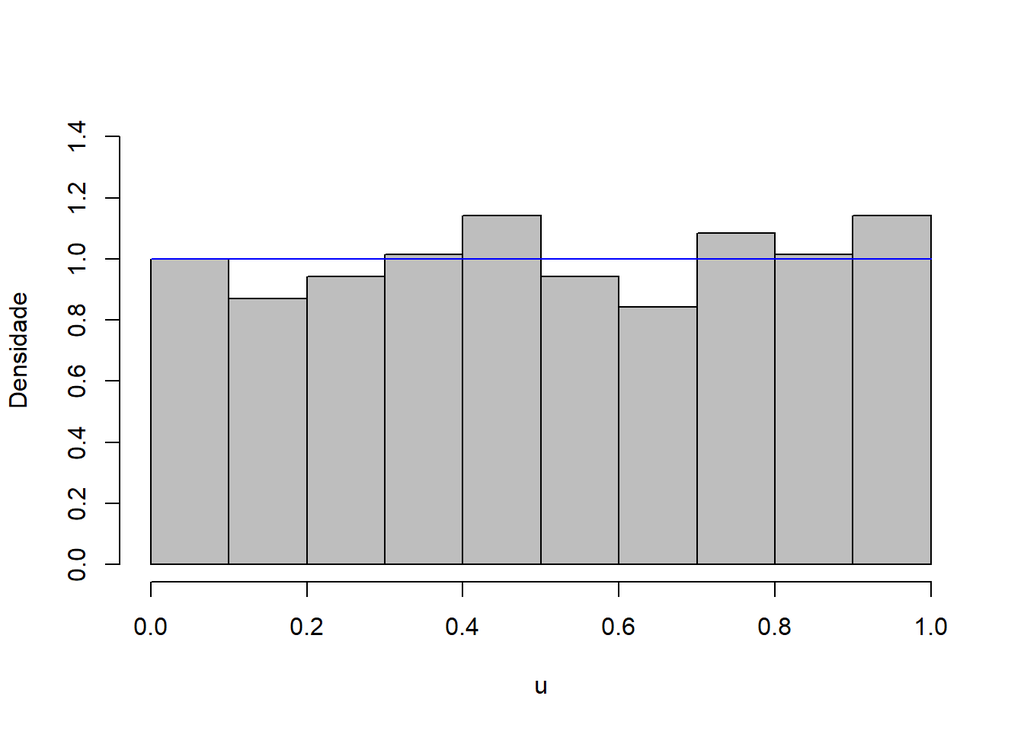

```r
kmax <- 700
a <- 7^(5);b <- 0;m <- 2^(31)-1
x <- rep(NA,kmax);x[1] <- 231
for(k in 1:(kmax-1)){x[k+1] <- (a*x[k]+b)%%m}
u <- x/m
classes <- seq(0,1,0.1)
hist(u,breaks=classes,freq=F,right=F,col="gray",ylim=c(0,1.4),xlab="u",ylab="Densidade",main="")
points(seq(0,1,0.1),dunif(seq(0,1,0.1),0,1),type="l",col="blue")
```

Existem muitas outras **receitas** para $a,b,m$ e $x_{1}$ que proporcionam bons geradores de números pseudo-aleatórios.

Daqui pra frente, pra simplificar a linguagem, números pseudo-aleatórios no intervalo $(0,1)$ serão chamados simplesmente de números aleatórios no intervalo $(0,1)$.

[Voltar ao topo](http://www.maurocampos.com/cursos/estcomp/simulna.html)

# 5 Números aleatórios no R

Vimos nas seções anteriores que números aleatórios no intervalo $(0,1)$ são os blocos construtivos básicos para gerar valores de uma distribuição $F$ não-uniforme. No R números aleatórios no intervalo $(0,1)$ são gerados usando a função `runif()`.

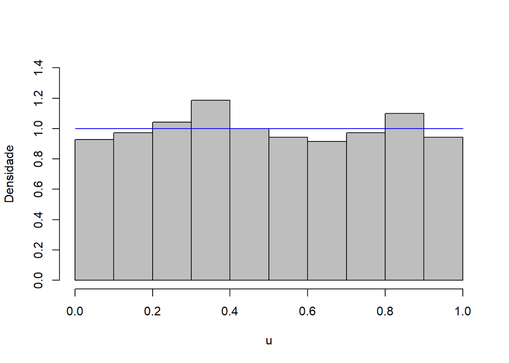

```r
runif(1)
## [1] 0.6742863
runif(5)
## [1] 0.4364369 0.2434952 0.9184869 0.4633911 0.5672392
runif(1,min=0,max=1)
## [1] 0.7809216
runif(5,min=0,max=1)
## [1] 0.6269475 0.3359254 0.7261285 0.8363981 0.1127674
set.seed(123)
u <- runif(700)
classes <- seq(0,1,0.1)
hist(u,breaks=classes,freq=F,right=F,col="gray",ylim=c(0,1.4),xlab="u",ylab="Densidade",main="")
points(seq(0,1,0.1),dunif(seq(0,1,0.1),0,1),type="l",col="blue")
```

[Voltar ao topo](http://www.maurocampos.com/cursos/estcomp/simulna.html)

# 6 Introdução à integração Monte Carlo

Uma aplicação imediata para números aleatórios no intervalo $(0,1)$ é a estimação de integrais. Vamos começar com a situação mais simples que é estimar a seguinte integral:

$$I=\int_{0}^{1}g(x)dx.$$
É simples ver que
$$I=E(g(U))$$
onde $U\sim U(0,1)$. Portanto, pela **lei dos grandes números** segue que
$$\bar{g}_{N}=\frac{1}{N}\sum_{k=1}^{N}g(U_{k})\stackrel{p}{\rightarrow}E(g(U))=I
\hspace{1.5cm}N\rightarrow\infty$$
onde $U_{1},\ldots,U_{N}\stackrel{iid}{\sim}U(0,1)$. Este resultado garante que se $N$ for suficientemente grande, então com alta probabilidade o valor de $I$ é bem aproximado por $\bar{g}_{k}$, ou seja,
$$I\approx\bar{g}_{N}=\frac{1}{N}\sum_{k=1}^{N}g(u_{k})$$
onde $u_{1},\ldots,u_{N}$ são $N$ números aleatórios no intervalo $(0,1)$. Este processo de estimação da integral $I$ é chamado **integração Monte Carlo**.

O seguinte **algoritmo** pode ser aplicado:

```
Algoritmo: estimação de I
Entrada: tol, Nmax
Saída: I.hat
  1 soma <- 0; N <- 0; I.hat <- 0
  2 N <- N+1
  3 I.old <- I.hat
  4 gere um número aleatório u
  5 soma <- soma + g(u)
  6 I.hat <- soma/N
  7 dif <- I.hat-I.old
  8 se (dif < tol) ou (N>Nmax) pare. Caso contrário volte para o passo 2
  9 retorna I.hat
```

Vejamos um exemplo ilustrativo simples: estimar $I=\int_{0}^{1}3x^{2}dx=1$.

```r
tol <- 0.00001; Nmax <- 1000
soma <- 0; N <- 0; I.hat <- 0
repeat{
  N <- N+1
  I.old <- I.hat
  soma <- soma + 3*(runif(1)^(2))
  I.hat <- soma/N
  dif <- abs(I.hat-I.old)
  if((dif<tol)|(N>Nmax)){break}
}
N
## [1] 420
I.hat
## [1] 0.9669233
c(I.hat,I.old,dif)
## [1] 9.669233e-01 9.669164e-01 6.892665e-06
```

De forma alternativa, poderíamos fazer também:

```r
N <- 1000
u <- runif(N)
g <- 3*(u^(2))
I.hat <- mean(g)
I.hat
## [1] 0.9974833
```

Cada uma das seguintes integrais

$$\int_{a}^{b}h(x)dx\hspace{1cm}\int_{0}^{+\infty}h(x)dx\hspace{1cm}\int_{-\infty}^{+\infty}h(x)dx$$
pode ser estimada por integração Monte Carlo após uma transformação de variável apropriada.

Por fim, a ideia geral da integração Monte Carlo pode ser extendida para o caso de integrais multidimensionais. De fato, basta ver que

$$I=\int_{0}^{1}\cdots\int_{0}^{1}g(x_{1},\ldots,x_{n})dx_{1}\cdots dx_{n}=E[g(U_{1},\ldots,U_{n})]$$
e que
$$I\approx\frac{1}{N}\sum_{k=1}^{N}g(u_{1}^{k},\ldots,u_{n}^{k})$$
onde $u_{1}^{k},\ldots,u_{n}^{k}$ são $n$ números aleatórios independentes para cada $k$ variando de $1$ até $N$.

[Voltar ao topo](http://www.maurocampos.com/cursos/estcomp/simulna.html)

# 7 Estimando $\pi$

Basta ver que

$$\frac{\pi}{4}=I=\Pr(A)=\int_{0}^{1}\int_{0}^{1}I_{A}(x,y)dxdy\hspace{2cm}
A=\{(x,y)\in[0,1]^{2}:(x-0.5)^{2}+(y-0.5)^{2}<0.25\}.$$
Portanto
$$\hat{\pi}\approx 4\cdot\hat{I}.$$
Assim

```r
N <- 20000
ux <- runif(N)
uy <- runif(N)
d2 <- (ux-0.5)^(2)+(uy-0.5)^(2)
aux1 <- which(d2<0.25)
aux2 <- length(aux1); aux2
## [1] 15712
I.hat <- aux2/N
I.hat
## [1] 0.7856
pi.hat <- 4*I.hat
pi.hat
## [1] 3.1424
```

[Voltar ao topo](http://www.maurocampos.com/cursos/estcomp/simulna.html)